# Raw Data Report

## (Not really all that) Quick & Dirty

- These are the raw data results for *most* of the variables for chapter 1 data
- NOTES: still missing tree diversity measures
- still missing street scale data (something weird happening there)

## Points of Discussion

- Comparable street segments
- Tree size skewness measurements
- Tree species richness + iNEXT
- CMA vs weighted census tracts
- Montreal DBHs aka what is happening here
- DSM correction (I think I need to correct for sea level)

## Workflow

[output not shown]

[output cut: 223 more lines]

[output not shown]

[interactive chart not shown]

## Tree Stuff

Number of trees per city:

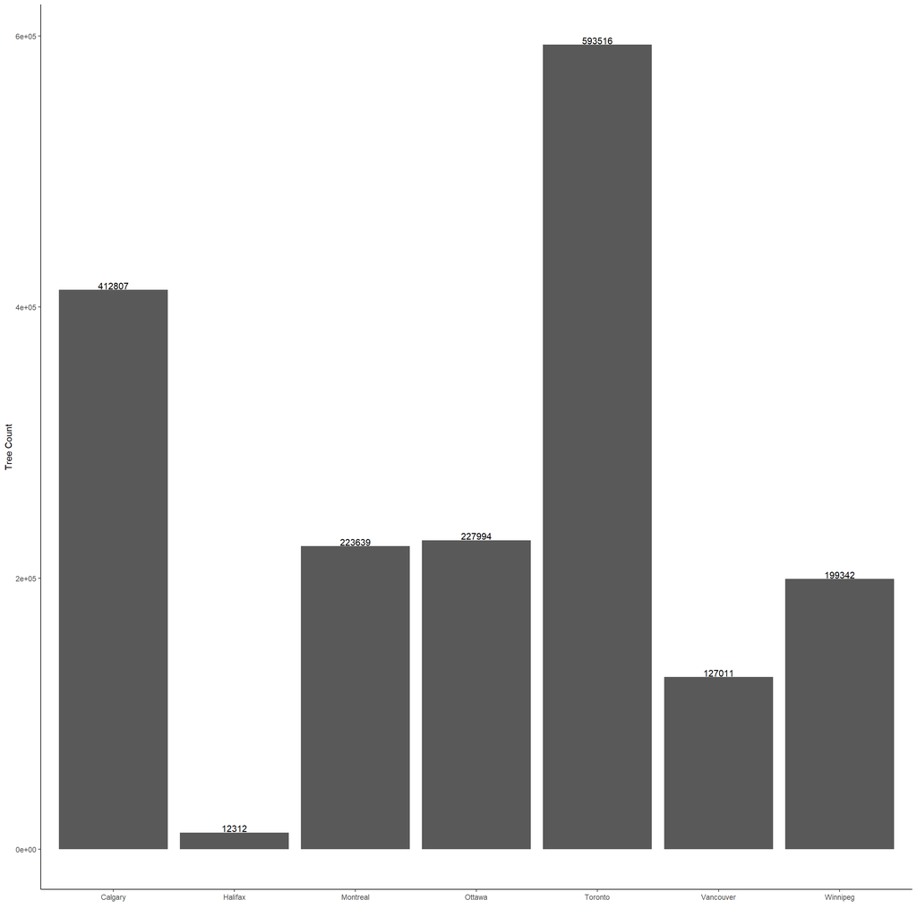

Number of tree **species** per city:

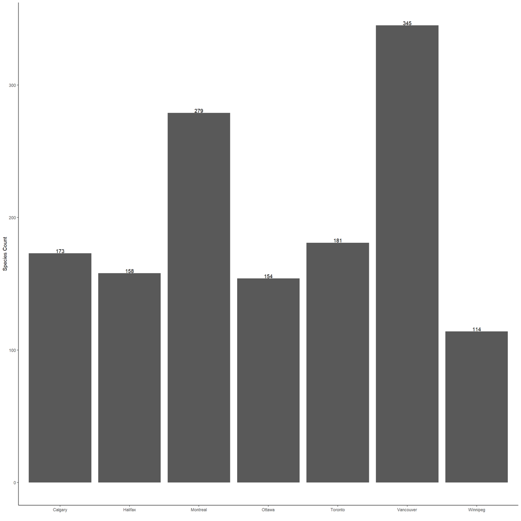

Tree size distribution per city:

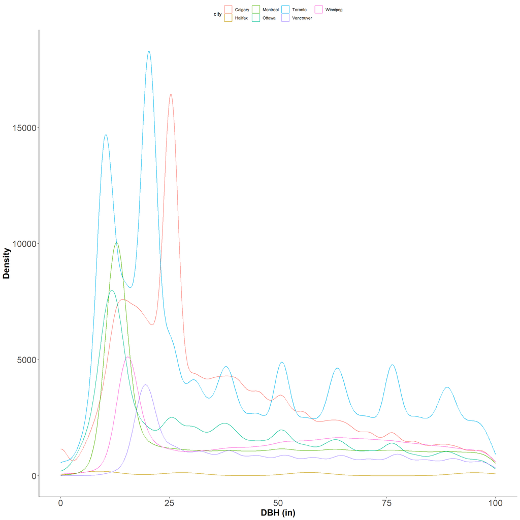

## City Scale (CMA level)

### Response Variables

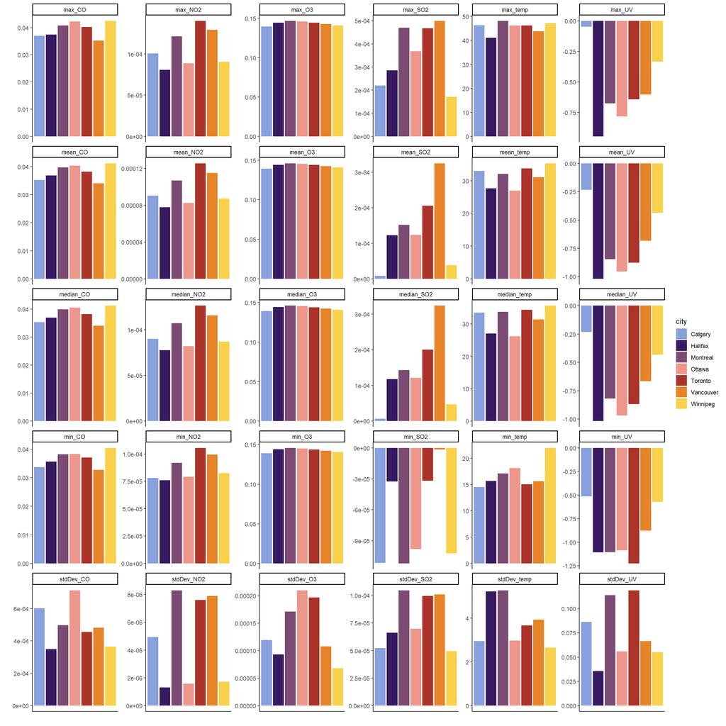

### Independent Variables - Trees

- currently missing diversity measures but have included tree size and tree density

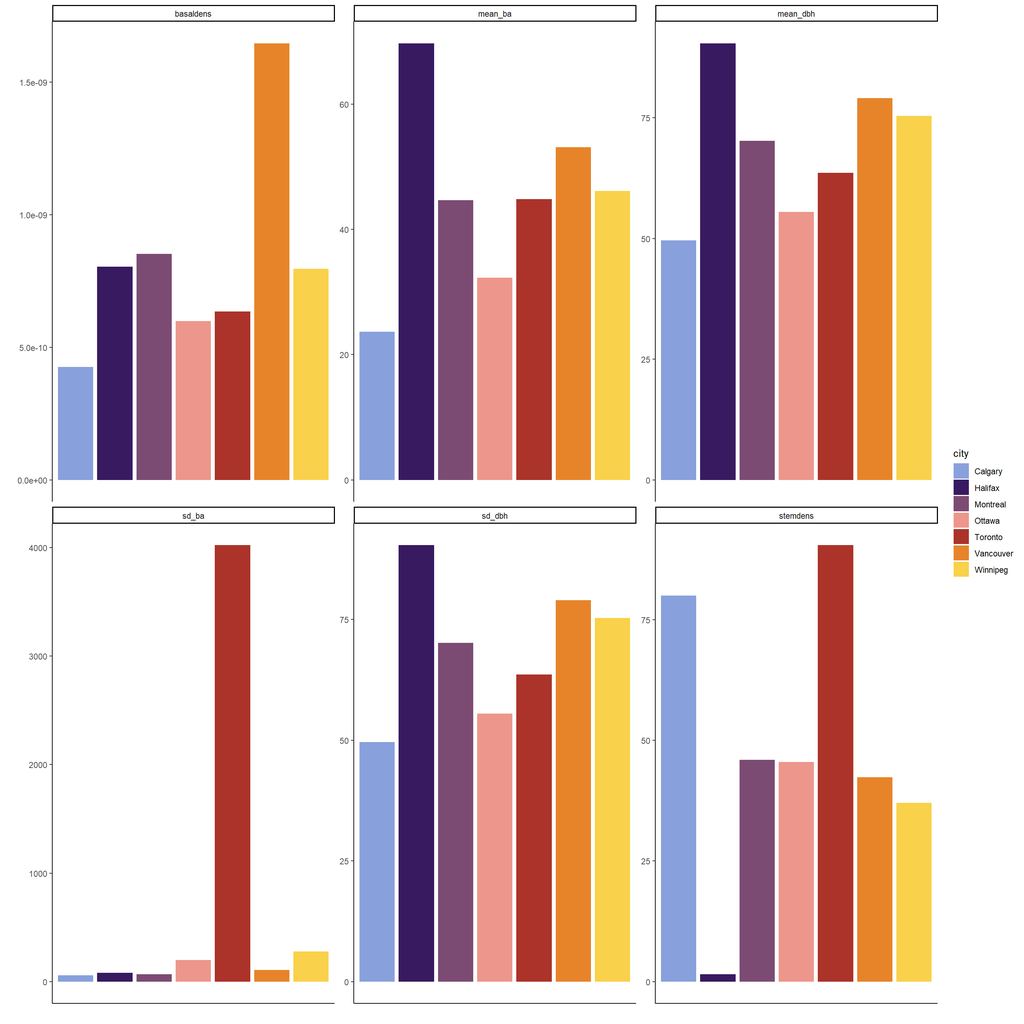